# Estadística para científicos de datos

## Caso Práctico

Autores:

- Enríquez Angel
- Franco Stefania
- Parra Lizzeth
- Salazar Wagner
- **Objetivo:** Investigar cómo las características de las pistas de Spotify afectan la popularidad de las canciones.
- **Problema:** ¿Qué características de las pistas de Spotify tienen el mayor impacto en la popularidad de las canciones?

```python
import random
import numpy as np
import pandas as pd
import matplotlib.pyplot as plt
import matplotlib.colors as mcolors
import seaborn as sns
pd.set_option("display.max_column", None)
colors = plt.cm.tab20(np.linspace(0, 1, 11))
```

# Carga

```python
df_raw = pd.read_csv("./spotify-tracks.csv", encoding="UTF-8", sep=",")
df_raw.head()
```

|  | Unnamed: 0 | track_id | artists | album_name | track_name | popularity | duration_ms | explicit | danceability | energy | key | loudness | mode | speechiness | acousticness | instrumentalness | liveness | valence | tempo | time_signature | track_genre |
| --- | --- | --- | --- | --- | --- | --- | --- | --- | --- | --- | --- | --- | --- | --- | --- | --- | --- | --- | --- | --- | --- |
| 0 | 0 | 5SuOikwiRyPMVoIQDJUgSV | Gen Hoshino | Comedy | Comedy | 73 | 230666 | False | 0.676 | 0.4610 | 1 | -6.746 | 0 | 0.1430 | 0.0322 | 0.000001 | 0.3580 | 0.715 | 87.917 | 4 | acoustic |
| 1 | 1 | 4qPNDBW1i3p13qLCt0Ki3A | Ben Woodward | Ghost (Acoustic) | Ghost - Acoustic | 55 | 149610 | False | 0.420 | 0.1660 | 1 | -17.235 | 1 | 0.0763 | 0.9240 | 0.000006 | 0.1010 | 0.267 | 77.489 | 4 | acoustic |
| 2 | 2 | 1iJBSr7s7jYXzM8EGcbK5b | Ingrid Michaelson;ZAYN | To Begin Again | To Begin Again | 57 | 210826 | False | 0.438 | 0.3590 | 0 | -9.734 | 1 | 0.0557 | 0.2100 | 0.000000 | 0.1170 | 0.120 | 76.332 | 4 | acoustic |
| 3 | 3 | 6lfxq3CG4xtTiEg7opyCyx | Kina Grannis | Crazy Rich Asians (Original Motion Picture Sou... | Can't Help Falling In Love | 71 | 201933 | False | 0.266 | 0.0596 | 0 | -18.515 | 1 | 0.0363 | 0.9050 | 0.000071 | 0.1320 | 0.143 | 181.740 | 3 | acoustic |
| 4 | 4 | 5vjLSffimiIP26QG5WcN2K | Chord Overstreet | Hold On | Hold On | 82 | 198853 | False | 0.618 | 0.4430 | 2 | -9.681 | 1 | 0.0526 | 0.4690 | 0.000000 | 0.0829 | 0.167 | 119.949 | 4 | acoustic |

# Limpieza

```python
df_process = df_raw.copy()
df_process.info()
```

```
<class 'pandas.core.frame.DataFrame'>
RangeIndex: 114000 entries, 0 to 113999
Data columns (total 21 columns):
 #   Column            Non-Null Count   Dtype
---  ------            --------------   -----
 0   Unnamed: 0        114000 non-null  int64
 1   track_id          114000 non-null  object
 2   artists           113999 non-null  object
 3   album_name        113999 non-null  object
 4   track_name        113999 non-null  object
 5   popularity        114000 non-null  int64
 6   duration_ms       114000 non-null  int64
 7   explicit          114000 non-null  bool
 8   danceability      114000 non-null  float64
 9   energy            114000 non-null  float64
 10  key               114000 non-null  int64
 11  loudness          114000 non-null  float64
 12  mode              114000 non-null  int64
 13  speechiness       114000 non-null  float64
 14  acousticness      114000 non-null  float64
 15  instrumentalness  114000 non-null  float64
 16  liveness          114000 non-null  float64
 17  valence           114000 non-null  float64
 18  tempo             114000 non-null  float64
 19  time_signature    114000 non-null  int64
 20  track_genre       114000 non-null  object
dtypes: bool(1), float64(9), int64(6), object(5)
memory usage: 17.5+ MB
```

Borrar nulos y columna *Unnamed:0*

```python
df_process = df_process.dropna()
df_process = df_process.drop(columns=["Unnamed: 0"])
df_process.info()
```

```
<class 'pandas.core.frame.DataFrame'>
Index: 113999 entries, 0 to 113999
Data columns (total 20 columns):
 #   Column            Non-Null Count   Dtype
---  ------            --------------   -----
 0   track_id          113999 non-null  object
 1   artists           113999 non-null  object
 2   album_name        113999 non-null  object
 3   track_name        113999 non-null  object
 4   popularity        113999 non-null  int64
 5   duration_ms       113999 non-null  int64
 6   explicit          113999 non-null  bool
 7   danceability      113999 non-null  float64
 8   energy            113999 non-null  float64
 9   key               113999 non-null  int64
 10  loudness          113999 non-null  float64
 11  mode              113999 non-null  int64
 12  speechiness       113999 non-null  float64
 13  acousticness      113999 non-null  float64
 14  instrumentalness  113999 non-null  float64
 15  liveness          113999 non-null  float64
 16  valence           113999 non-null  float64
 17  tempo             113999 non-null  float64
 18  time_signature    113999 non-null  int64
 19  track_genre       113999 non-null  object
dtypes: bool(1), float64(9), int64(5), object(5)
memory usage: 17.5+ MB
```

Convertir variables categóricas

```python
pitch_class_dict = {
    0: 'C',
    1: 'C♯',
    2: 'D',
    3: 'D♯',
    4: 'E',
    5: 'F',
    6: 'F♯',
    7: 'G',
    8: 'G♯',
    9: 'A',
    10: 'B♭',
    11: 'B'
}

mode={
    0: "Escala Menor",
    1: "Escala Mayor"
}


df_process["key"] = df_process["key"].apply(lambda key: pitch_class_dict[key] if key in pitch_class_dict.keys() else "C")
df_process["key"] = pd.Categorical(df_process["key"])
df_process["mode"] = df_process["mode"].apply(lambda x: mode[x])
df_process["mode"] = pd.Categorical(df_process["mode"])
df_process["time_signature"] = pd.Categorical(df_process["time_signature"])
```

Duración a minutos

```python
df_process["duration_ms"] = df_process["duration_ms"] / (1000 * 60)
df_process.rename(columns={"duration_ms":"duration_min"}, inplace=True)
```

# Variables

**Variables independientes:** duration_min, explicit, danceability, energy, key, loudness, mode, speechiness, acousticness, instrumentalness, liveness, valence, tempo, time_signature, track_genre.

**Variable dependiente:** popularity.

**Tipo de variables:** Continuas y discretas

# Análisis Exploratorio

## Variables Continuas

### Popularidad

Distribución de la popularidad

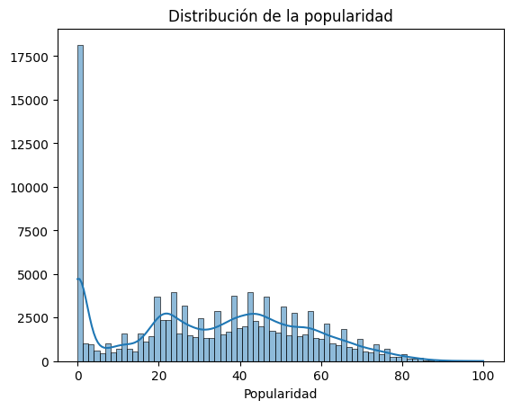

```python
sns.histplot(df_process["popularity"], kde=True)
plt.title("Distribución de la popularidad")
plt.ylabel("")
plt.xlabel("Popularidad")
plt.show()
```

```python
df_process = df_process[df_process["popularity"] != 0]
print(f'{len(df_process)} registros tiene popularidad diferente a 0')
```

```
97980 registros tiene popularidad diferente a 0
```

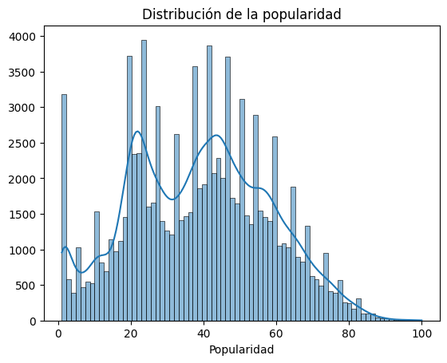

```python
sns.histplot(df_process["popularity"], kde=True)
plt.title("Distribución de la popularidad")
plt.ylabel("")
plt.xlabel("Popularidad")
plt.show()
```

```python
df_process.describe().transpose().drop(columns=["count"])
```

|  | mean | std | min | 25% | 50% | 75% | max |
| --- | --- | --- | --- | --- | --- | --- | --- |
| popularity | 38.673127 | 19.201246 | 1.000000 | 23.000000 | 39.00000 | 53.000000 | 100.00000 |
| duration_min | 3.839890 | 1.844892 | 0.404433 | 2.924133 | 3.58970 | 4.422883 | 87.28825 |
| danceability | 0.565668 | 0.172703 | 0.000000 | 0.456000 | 0.57800 | 0.693000 | 0.98500 |
| energy | 0.645716 | 0.250406 | 0.000000 | 0.475000 | 0.68700 | 0.858000 | 1.00000 |
| loudness | -8.265888 | 4.987856 | -49.531000 | -10.057000 | -7.07100 | -5.027000 | 4.53200 |
| speechiness | 0.086405 | 0.110205 | 0.000000 | 0.035900 | 0.04900 | 0.085600 | 0.96500 |
| acousticness | 0.310722 | 0.329796 | 0.000000 | 0.014700 | 0.16700 | 0.589000 | 0.99600 |
| instrumentalness | 0.164786 | 0.316083 | 0.000000 | 0.000000 | 0.00006 | 0.072725 | 1.00000 |
| liveness | 0.217925 | 0.195809 | 0.000000 | 0.098500 | 0.13300 | 0.280000 | 1.00000 |
| valence | 0.468711 | 0.258619 | 0.000000 | 0.254000 | 0.45500 | 0.675000 | 0.99500 |
| tempo | 122.682976 | 29.963442 | 0.000000 | 99.966000 | 122.74350 | 141.091000 | 243.37200 |

Posterior a la eliminación de los registros con popularidad = 0 se analiza la distribución final de la popularidad. La mayoría de canciones tienen una popularidad menor a 53. Con picos al rededor del 25% y la mediana

### Duración

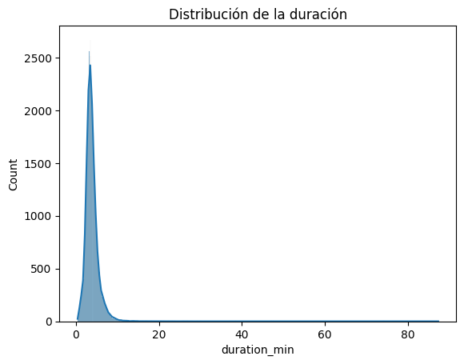

```python
sns.histplot(df_process["duration_min"], kde=True)
plt.title("Distribución de la duración")
plt.show()
```

En la distribución de arriba se puede observar que la mayoría de canciones (75%) no supera los 5 minutos en duración. Se entiende que los tracks con una duración mayor corresponden a pistas estilo "mix" o incluso "podcast". Bajo este criterio se eliminan del dataset los registros con una duración mayor a 10 minutos

```python
df_process = df_process[df_process["duration_min"] <= 10]
print(f'{len(df_process)} registros tienen una duración menor o igual a 10 minutos. Se entiende que este dataset contiene unicamente registros de canciones')
```

```
97447 registros tienen una duración menor o igual a 10 minutos. Se entiende que este dataset contiene unicamente registros de canciones
```

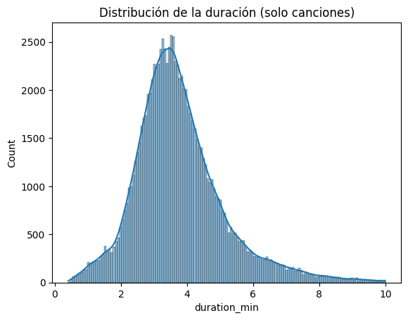

```python
sns.histplot(df_process["duration_min"], kde=True)
plt.title("Distribución de la duración (solo canciones)")
plt.show()
```

### Otras variables

```python
df_process.describe().transpose().drop(columns="count")
```

|  | mean | std | min | 25% | 50% | 75% | max |
| --- | --- | --- | --- | --- | --- | --- | --- |
| popularity | 38.732490 | 19.202155 | 1.000000 | 23.000000 | 39.000000 | 53.0000 | 100.000000 |
| duration_min | 3.773517 | 1.358813 | 0.404433 | 2.920833 | 3.583767 | 4.4040 | 9.999983 |
| danceability | 0.566291 | 0.172178 | 0.000000 | 0.457000 | 0.578000 | 0.6930 | 0.985000 |
| energy | 0.646194 | 0.250202 | 0.000000 | 0.476000 | 0.688000 | 0.8580 | 1.000000 |
| loudness | -8.245831 | 4.973989 | -49.531000 | -10.032000 | -7.056000 | -5.0205 | 4.532000 |
| speechiness | 0.086280 | 0.109632 | 0.000000 | 0.035800 | 0.049000 | 0.0857 | 0.965000 |
| acousticness | 0.310328 | 0.329527 | 0.000000 | 0.014700 | 0.166000 | 0.5880 | 0.996000 |
| instrumentalness | 0.163371 | 0.314969 | 0.000000 | 0.000000 | 0.000058 | 0.0682 | 1.000000 |
| liveness | 0.217607 | 0.195409 | 0.000000 | 0.098500 | 0.133000 | 0.2800 | 1.000000 |
| valence | 0.469526 | 0.258329 | 0.000000 | 0.256000 | 0.456000 | 0.6760 | 0.995000 |
| tempo | 122.704881 | 29.974808 | 0.000000 | 99.966000 | 122.758000 | 141.1695 | 243.372000 |

Histogramas para otras variables continuas

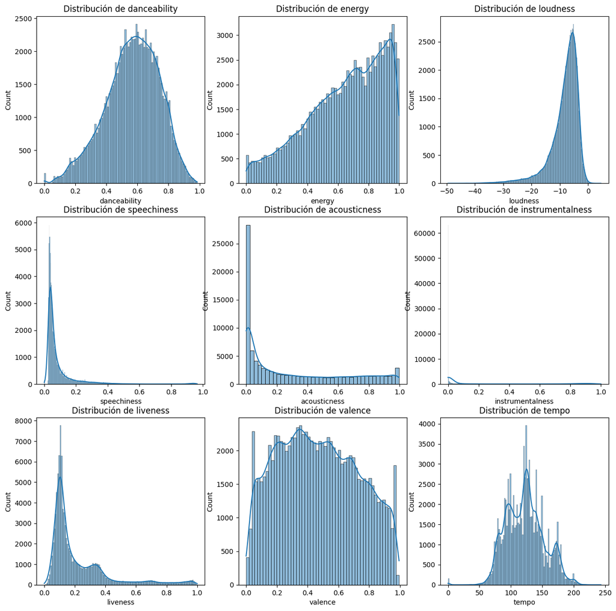

```python
fig, axes = plt.subplots(3, 3, figsize=(15, 5 * 3))
i = 0
j = 0
for col in df_process.columns:
    if(col in ("popularity", "duration_min")):
        continue
    if(df_process[col].dtype in ["int64", "float64"]):
        sns.histplot(df_process[col], kde=True, ax=axes[i][j])
        axes[i][j].set_title(f"Distribución de {col}")
        j += 1
        if(j==3):
            j=0
            i+=1
```

**Conclusiones**

- La mayoría de registros tiene un índice de *bailabilidad* alrededor de 0.6
- La mayor cantidad de registros en el dataset tiene un alto indece de energía
- La mayoría de registros tiene un volumen alto, con respecto a la referencia 0dB
- La mayoría de registros tiene un índice bajo de palabras habladas
- La mayoría de registros tiene una bajo índice de acústica en su música
- La mayoría de registros tiene letra, es decir no son instrumentales
- La mayoría de regsitros no son grabados en vivo
- La mayoría de registros tiene un tempo alrededor de 125 BPM

**Diagramas de disperción** Se gráfica cada caracterísica numérica continua con respecto a la popularidad

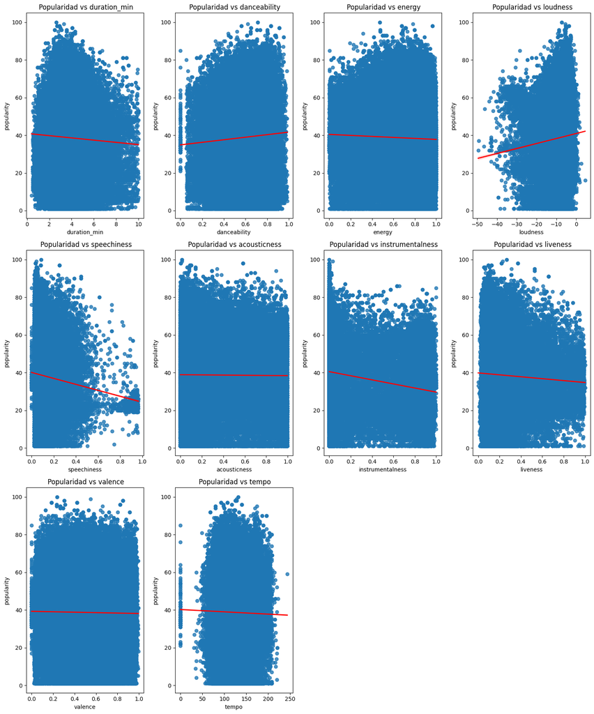

```python
fig, axes = plt.subplots(3, 4, figsize=(15, 6 * 3))
i = 0
j = 0
for col in df_process.columns:
    if(col in ("popularity")):
        continue
    if(df_process[col].dtype in ["int64", "float64"]):
        sns.regplot(x=df_process[col],y=df_process["popularity"] ,ax=axes[i][j], line_kws={'color': 'red', 'linewidth': 2})
        axes[i][j].set_title(f" Popularidad vs {col}")
        j += 1
        if(j==4):
            j=0
            i+=1
fig.delaxes(axes[2][2])
fig.delaxes(axes[2][3])
plt.tight_layout()
plt.show()
```

**Conclusiones**

De las gráficas anteriores se puede obtener las siguientes conclusiones:

- Existe una correlación negativa, posiblemente débil entre la duración y la popularidad
- Existe una correlación positiva, posiblemente débil entre el indice de *bailabilidad* y popularidad.
- Existe una correlación negativa, posiblemente débil entre el índice de energía y la popularidad
- Existe una correlación positiva entre el volumen y la popularidad, aparentemente canciones con un volumen más alto son más populares
- Existe una correlación negativa entre la cantidad de palabras de una canción y su popularidad
- Existe una correlación negativa, posiblemente débil pero aún así considerable entre instrumentalidad y la popularidad

Las conclusiones de arriba se ratifican mediente una matriz de correlación expresada con ayuda de un mapa de calor.

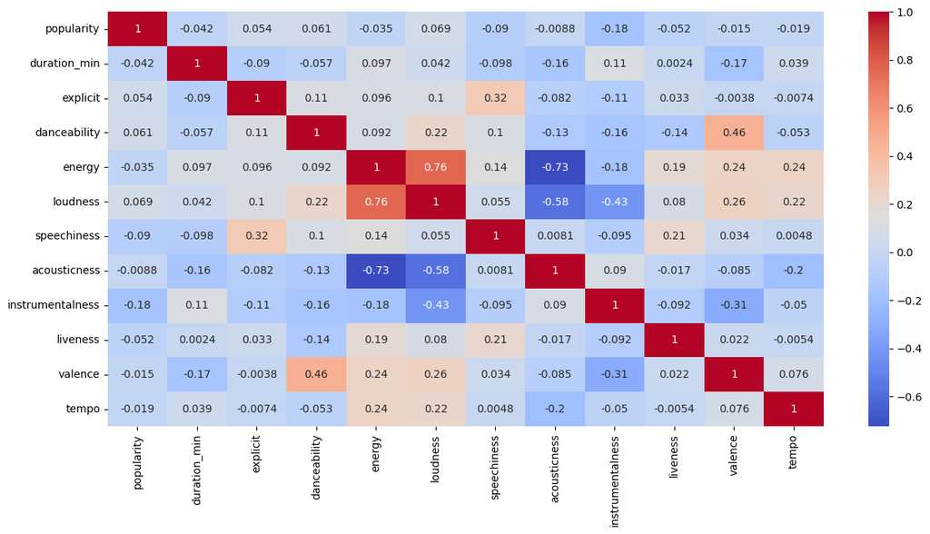

```python
corr_matrix = df_process.corr(numeric_only=True)
# display(corr_matrix)
plt.figure(figsize=(15,7))
sns.heatmap(corr_matrix, annot=True, cmap="coolwarm")
plt.show()
```

El mapa de calor y sus valores numeros confirman las correlaciones descatadas mediante la interpretación de los patrones en los diagramas de disperción. Es importante destacar que la correlación más importante con la popularidad corresponde a la instrumentalidad de una canción de Spotify.

El análisis previamente realizado no es concluyente, ninguna de las variables continuas mantiene una fuerte relación con la popularidad

## Variables discretas

### Explicit

|  | Explícito | popularity |
| --- | --- | --- |
| 0 | False | 38.411098 |
| 1 | True | 42.137299 |

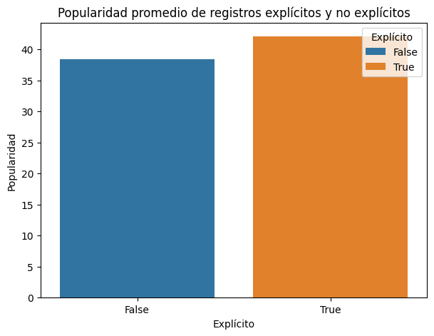

```python
temp_1 = df_process.groupby(by=["explicit"])["popularity"].mean().reset_index().rename(columns={"explicit":"Explícito"})
display(temp_1)
plt.figure(figsize=(7,5))
sns.barplot(data=temp_1, x="Explícito", y="popularity", hue="Explícito")
plt.title("Popularidad promedio de registros explícitos y no explícitos")
plt.ylabel("Popularidad")
plt.xlabel("Explícito")
plt.show()
```

Las canciones con contenido explícito son, en promedio, más populares que las canciones sin contenido explícito. Es posible concluir que existe una relación entre la variable *explicit* y la popularidad de una canción

### Key (nota)

|  | key | popularity |
| --- | --- | --- |
| 0 | A | 38.114168 |
| 1 | B | 39.274991 |
| 2 | B♭ | 38.486581 |
| 3 | C | 38.708787 |
| 4 | C♯ | 38.544285 |
| 5 | D | 39.043521 |
| 6 | D♯ | 39.417087 |
| 7 | E | 39.196715 |
| 8 | F | 38.936305 |
| 9 | F♯ | 39.206840 |
| 10 | G | 37.531367 |
| 11 | G♯ | 39.596592 |

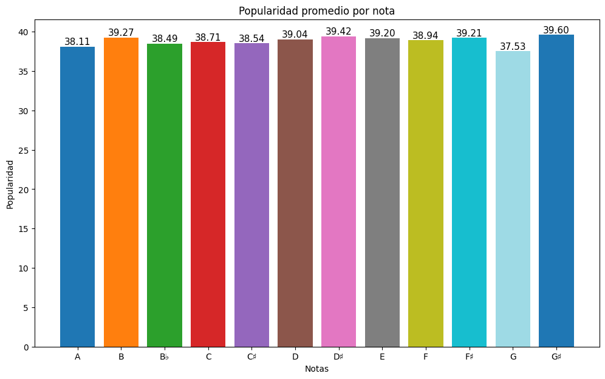

```python
temp_2 = df_process.groupby(by=["key"], observed=True)["popularity"].mean().reset_index()
display(temp_2)
plt.figure(figsize=(12,7))
bars = plt.bar(temp_2["key"], temp_2["popularity"], color=colors[:len(temp_2)])
for bar, value in zip(bars, temp_2["popularity"]):
    plt.text(bar.get_x() + bar.get_width() / 2, bar.get_height(), f"{value:.2f}", ha='center', va='bottom', fontsize=11)
plt.title("Popularidad promedio por nota")
plt.ylabel("Popularidad")
plt.xlabel("Notas")
plt.show()
```

### Mode (Escala)

|  | mode | popularity |
| --- | --- | --- |
| 0 | Escala Mayor | 38.645099 |
| 1 | Escala Menor | 38.884246 |

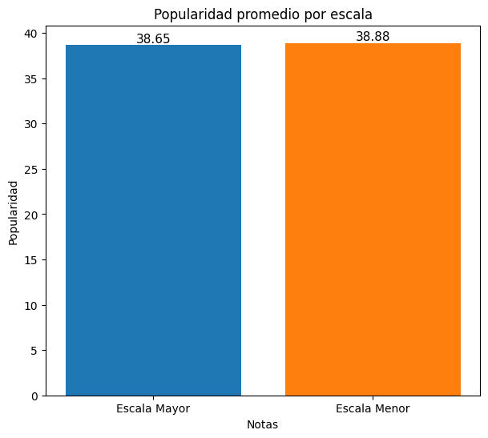

```python
temp_3 = df_process.groupby(by="mode", observed=True)["popularity"].mean().reset_index()
display(temp_3)
plt.figure(figsize=(7,6))
bars = plt.bar(temp_3["mode"], temp_3["popularity"], color=colors[:len(temp_3)])
for bar, value in zip(bars, temp_3["popularity"]):
    plt.text(bar.get_x() + bar.get_width() / 2, bar.get_height(), f"{value:.2f}", ha='center', va='bottom', fontsize=11)
plt.title("Popularidad promedio por escala")
plt.ylabel("Popularidad")
plt.xlabel("Notas")
plt.show()
```

Como se puede observar no existe una diferencia considerable en el promedio de la popularidad por escala. Se concluye que esta variable no está relacionada con la popularidad.

### Time Signature (Compás)

|  | time_signature | popularity |
| --- | --- | --- |
| 0 | 0 | 38.006369 |
| 1 | 1 | 33.489183 |
| 2 | 3 | 36.194173 |
| 3 | 4 | 39.075376 |
| 4 | 5 | 34.445395 |

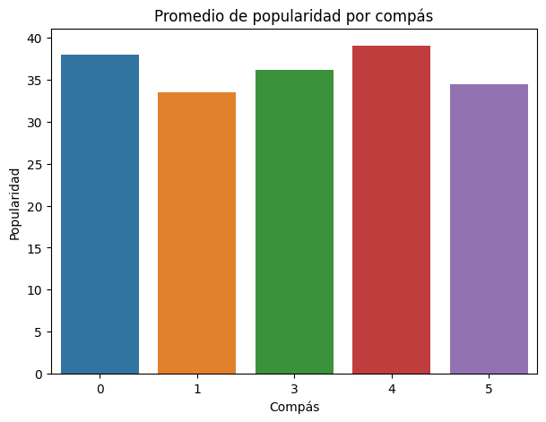

```python
temp_4 = df_process.groupby(by=["time_signature"], observed=True)["popularity"].mean().reset_index()
display(temp_4)
plt.figure(figsize=(7,5))
sns.barplot(data=temp_4, y="popularity", x="time_signature", hue="time_signature")
plt.ylabel("Popularidad")
plt.xlabel("Compás")
plt.title("Promedio de popularidad por compás")
# plt.legend(bbox_to_anchor=(1.05, 1), loc='upper left')
plt.legend([], [], frameon=False)
plt.show()
```

### Género

|  | track_genre | popularity |
| --- | --- | --- |
| 81 | pop-film | 59.402207 |
| 65 | k-pop | 59.298117 |
| 80 | pop | 58.161369 |
| 31 | electro | 57.905297 |
| 53 | house | 57.212730 |
| 15 | chill | 55.886458 |
| 71 | metal | 55.002525 |
| 30 | edm | 54.909091 |
| 57 | indie-pop | 54.867746 |
| 56 | indie | 54.474790 |
| 94 | sad | 53.122718 |
| 51 | hip-hop | 53.100000 |
| 2 | alt-rock | 52.141538 |
| 83 | progressive-house | 51.975446 |
| 44 | grunge | 51.553015 |
| 103 | soul | 50.886889 |
| 33 | emo | 50.573081 |
| 79 | piano | 50.191796 |
| 55 | indian | 50.152749 |
| 99 | singer-songwriter | 50.149867 |

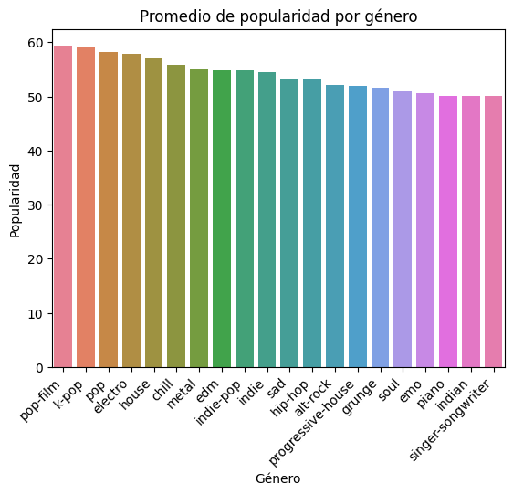

```python
temp_4 = df_process.groupby(by=["track_genre"], observed=True)["popularity"].mean().reset_index().sort_values(by=["popularity"], ascending=False)
temp_4 = temp_4.head(20)
display(temp_4)
sns.barplot(data=temp_4, x="track_genre", y="popularity", hue="track_genre")
plt.title("Promedio de popularidad por género")
plt.xlabel("Género")
plt.ylabel("Popularidad")
plt.xticks(rotation=45, ha="right")
plt.show()
```

En el gráfico de arriba se puede observar un patrón de comportamiento pudiendo afirmar que cada género tiene un valor distinto de popularidad promedio.

Con el fin de identificar si esta variable discreta tiene un impacto en la popularidad se gráfica un boxplot para visualizar la distribución de la popularidad en cada uno de los 20 géneros más populares en promedio.

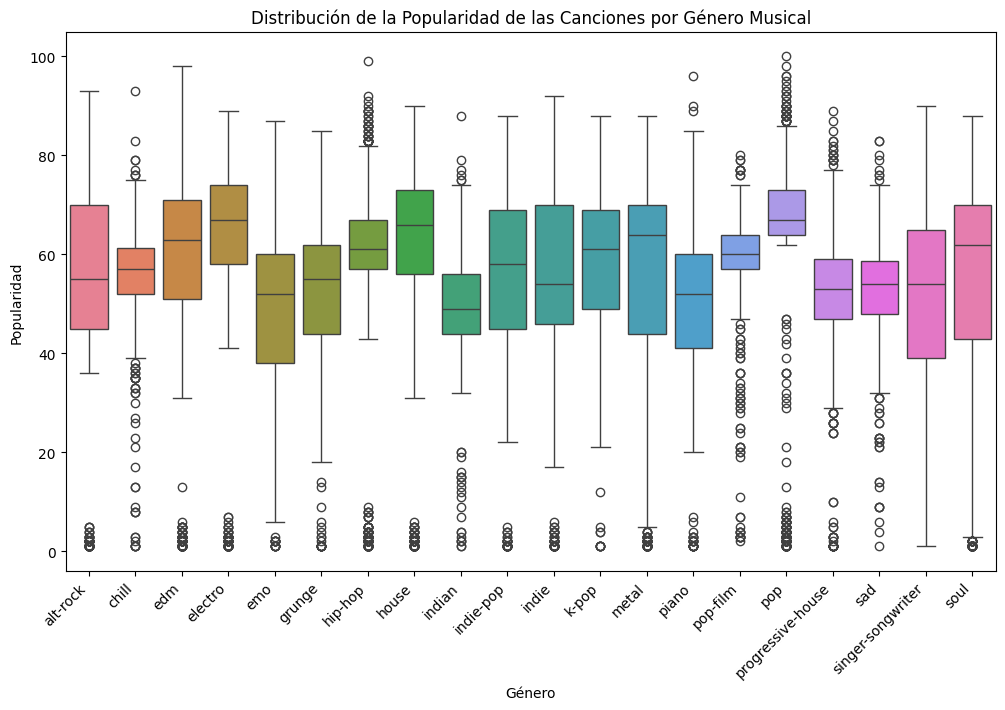

```python
plt.figure(figsize=(12,7))
sns.boxplot(data=df_process[df_process["track_genre"].isin(temp_4["track_genre"])],
            x="track_genre",
            y="popularity",
            hue="track_genre")
plt.title("Distribución de la Popularidad de las Canciones por Género Musical")
plt.xlabel("Género")
plt.ylabel("Popularidad")
plt.xticks(rotation=45, ha="right")
plt.show()
```

El boxplot de arriba muestra una distribución de la popularidad altamente diferente para cada género musical, es así que podemos concluir que el género tiene un fuerte impacto en la popularidad de una canción en Spotify.

# Regresión Lineal

```python
from sklearn.linear_model import LinearRegression
from sklearn.model_selection import train_test_split
SEED = 1508
```

```python
df_rl = df_process.copy()
df_rl = df_rl.drop(columns=["track_id", "artists", "album_name", "track_name"])
X = df_rl.drop(columns=["popularity"])
X = pd.get_dummies(X, columns=['explicit', 'key', 'mode', 'time_signature', 'track_genre'])
y = df_rl["popularity"].reset_index().drop(columns=["index"])
```

```python
model = LinearRegression()
model.fit(X,y)
```

```
LinearRegression()
```

```python
coef = model.coef_.flatten()
coef_df_rl = pd.DataFrame(coef, index=X.columns, columns=["Coeficients"])
coef_df_rl = coef_df_rl.sort_values(by=["Coeficients"], ascending=False)
coef_df_rl = coef_df_rl.reset_index().rename(columns={"index":"Characteristic"})
df_mostInfluent_positive = coef_df_rl.head(10)
df_mostInfluent_negative = coef_df_rl.tail(10)
print("Características más influyentes positivamente con relación la popularidad")
display(df_mostInfluent_positive)
print("Características más influyentes negativamente con relación la popularidad")
display(df_mostInfluent_negative)
```

```
Características más influyentes positivamente con relación la popularidad
```

|  | Characteristic | Coeficients |
| --- | --- | --- |
| 0 | track_genre_pop-film | 20.202449 |
| 1 | track_genre_k-pop | 19.957703 |
| 2 | track_genre_pop | 18.190961 |
| 3 | track_genre_electro | 17.409155 |
| 4 | track_genre_house | 16.874486 |
| 5 | track_genre_metal | 15.936390 |
| 6 | track_genre_chill | 15.583450 |
| 7 | track_genre_indie-pop | 14.856113 |
| 8 | track_genre_edm | 14.721448 |
| 9 | track_genre_indie | 14.562248 |

```
Características más influyentes negativamente con relación la popularidad
```

|  | Characteristic | Coeficients |
| --- | --- | --- |
| 135 | track_genre_tango | -18.650044 |
| 136 | track_genre_latin | -19.824847 |
| 137 | track_genre_idm | -21.815481 |
| 138 | track_genre_grindcore | -22.538424 |
| 139 | track_genre_honky-tonk | -22.663608 |
| 140 | track_genre_kids | -23.961726 |
| 141 | track_genre_chicago-house | -26.046154 |
| 142 | track_genre_detroit-techno | -26.704447 |
| 143 | track_genre_romance | -29.888114 |
| 144 | track_genre_iranian | -30.410168 |

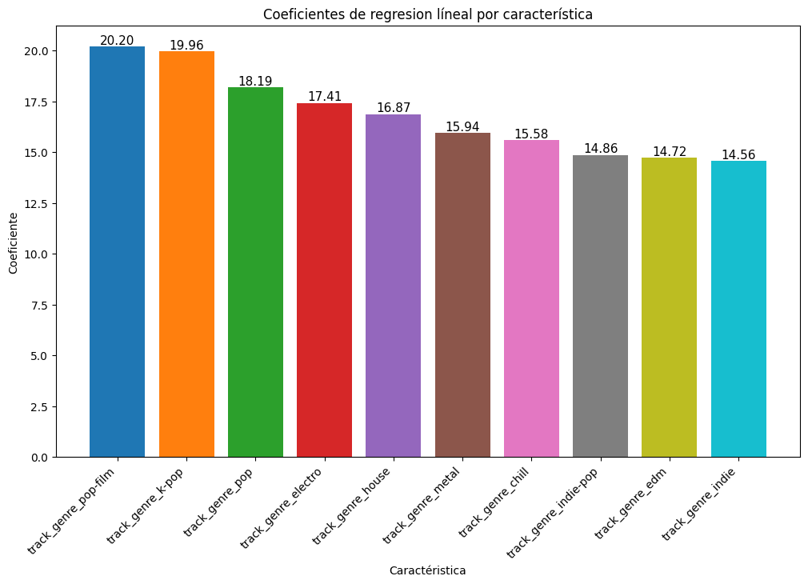

```python
plt.figure(figsize=(12,7))
bars = plt.bar(df_mostInfluent_positive["Characteristic"], df_mostInfluent_positive["Coeficients"], color=colors[:len(df_mostInfluent_positive)])
for bar, value in zip(bars, df_mostInfluent_positive["Coeficients"]):
    plt.text(bar.get_x() + bar.get_width() / 2, bar.get_height(), f"{value:.2f}", ha='center', va='bottom', fontsize=11)
plt.title("Coeficientes de regresion líneal por característica")
plt.xlabel("Caractéristica")
plt.ylabel("Coeficiente")
plt.xticks(rotation=45, ha="right")
plt.show()
```

**Géneros con Coeficientes Positivos:**

- Pop-Film (20.20), K-Pop (19.96), Pop (18.19): Estos géneros están asociados con un aumento significativo en la popularidad.
- Electro (17.41), House (16.87): Otros géneros de música electrónica también tienen un impacto positivo notable en la popularidad.

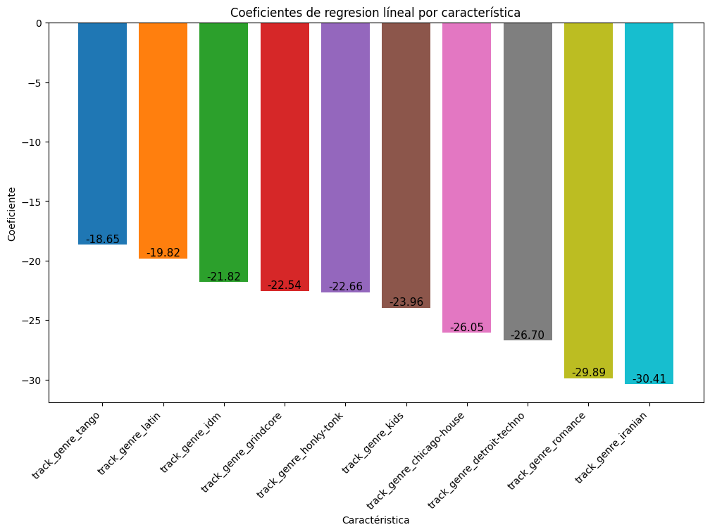

```python
plt.figure(figsize=(12,7))
bars = plt.bar(df_mostInfluent_negative["Characteristic"], df_mostInfluent_negative["Coeficients"], color=colors[:len(df_mostInfluent_negative)])
for bar, value in zip(bars, df_mostInfluent_negative["Coeficients"]):
    plt.text(bar.get_x() + bar.get_width() / 2, bar.get_height(), f"{value:.2f}", ha='center', va='bottom', fontsize=11)
plt.title("Coeficientes de regresion líneal por característica")
plt.xlabel("Caractéristica")
plt.ylabel("Coeficiente")
plt.xticks(rotation=45, ha="right")
plt.show()
```

**2. Géneros con Coeficientes Negativos:**

- Iranian (-30.41), Romance (-29.89), Detroit-Techno (-26.70): Estos géneros tienen un impacto negativo significativo en la popularidad.
- Chicago-House (-26.05), Kids (-23.96): Otros géneros con coeficientes negativos, lo que sugiere una menor popularidad.

```python
coef_df_rl[coef_df_rl["Characteristic"].isin(["explicit_True", "danceability","loudness", "speechiness", "valance"])]
```

|  | Characteristic | Coeficients |
| --- | --- | --- |
| 51 | danceability | 3.511393 |
| 70 | explicit_True | 1.127698 |
| 76 | loudness | 0.220374 |
| 112 | speechiness | -6.640177 |

# Conclusiones

- Géneros Populares: Géneros como Pop-Film, K-Pop y Pop están asociados con un aumento significativo en la popularidad.
- Géneros Menos Populares: Géneros como Iranian, Romance y Detroit-Techno tienen un impacto negativo notable en la popularidad.
- Impacto de Características Musicales: Características como la bailabilidad y el volumen tienen un impacto positivo en la popularidad, mientras que características como la habladuría tienen un impacto negativo.
- El género es la caracterísitica más influyente en la popularidad. Se aconseja a cualquier artista concentrar sus esfuerzo en géneros como pop-film, k-pop, pop, electro y house. Producciones en estos géneros serán más populares que en cualquier otro